# cyber_security

```python
import warnings
warnings.filterwarnings('ignore')

import pandas as pd
import numpy as np
import matplotlib.pyplot as plt
import seaborn as sns
```

```python
df = pd.read_csv('dataset.csv')
df.head()
```

|  | index | having_IPhaving_IP_Address | URLURL_Length | Shortining_Service | having_At_Symbol | double_slash_redirecting | Prefix_Suffix | having_Sub_Domain | SSLfinal_State | Domain_registeration_length | ... | popUpWidnow | Iframe | age_of_domain | DNSRecord | web_traffic | Page_Rank | Google_Index | Links_pointing_to_page | Statistical_report | Result |
| --- | --- | --- | --- | --- | --- | --- | --- | --- | --- | --- | --- | --- | --- | --- | --- | --- | --- | --- | --- | --- | --- |
| 0 | 1 | -1 | 1 | 1 | 1 | -1 | -1 | -1 | -1 | -1 | ... | 1 | 1 | -1 | -1 | -1 | -1 | 1 | 1 | -1 | -1 |
| 1 | 2 | 1 | 1 | 1 | 1 | 1 | -1 | 0 | 1 | -1 | ... | 1 | 1 | -1 | -1 | 0 | -1 | 1 | 1 | 1 | -1 |
| 2 | 3 | 1 | 0 | 1 | 1 | 1 | -1 | -1 | -1 | -1 | ... | 1 | 1 | 1 | -1 | 1 | -1 | 1 | 0 | -1 | -1 |
| 3 | 4 | 1 | 0 | 1 | 1 | 1 | -1 | -1 | -1 | 1 | ... | 1 | 1 | -1 | -1 | 1 | -1 | 1 | -1 | 1 | -1 |
| 4 | 5 | 1 | 0 | -1 | 1 | 1 | -1 | 1 | 1 | -1 | ... | -1 | 1 | -1 | -1 | 0 | -1 | 1 | 1 | 1 | 1 |

5 rows × 32 columns

# Determine the number of samples present in the data, unique elements in all the features.

```python
df.shape
```

```
(11055, 32)
```

```python
df.size
```

```
353760
```

```python
df.columns
```

```
Index(['index', 'having_IPhaving_IP_Address', 'URLURL_Length',
       'Shortining_Service', 'having_At_Symbol', 'double_slash_redirecting',
       'Prefix_Suffix', 'having_Sub_Domain', 'SSLfinal_State',
       'Domain_registeration_length', 'Favicon', 'port', 'HTTPS_token',
       'Request_URL', 'URL_of_Anchor', 'Links_in_tags', 'SFH',
       'Submitting_to_email', 'Abnormal_URL', 'Redirect', 'on_mouseover',
       'RightClick', 'popUpWidnow', 'Iframe', 'age_of_domain', 'DNSRecord',
       'web_traffic', 'Page_Rank', 'Google_Index', 'Links_pointing_to_page',
       'Statistical_report', 'Result'],
      dtype='object')
```

```python
for col in df.columns:
    uni = df[col].unique()
    print(f'{col} : {uni}\n')
```

```
index : [    1     2     3 ... 11053 11054 11055]

having_IPhaving_IP_Address : [-1  1]

URLURL_Length : [ 1  0 -1]

Shortining_Service : [ 1 -1]

having_At_Symbol : [ 1 -1]

double_slash_redirecting : [-1  1]

Prefix_Suffix : [-1  1]

having_Sub_Domain : [-1  0  1]

SSLfinal_State : [-1  1  0]

Domain_registeration_length : [-1  1]

Favicon : [ 1 -1]

port : [ 1 -1]

HTTPS_token : [-1  1]

Request_URL : [ 1 -1]

URL_of_Anchor : [-1  0  1]

Links_in_tags : [ 1 -1  0]

SFH : [-1  1  0]

Submitting_to_email : [-1  1]

Abnormal_URL : [-1  1]

Redirect : [0 1]

```

[output cut: 8 more lines]

```
age_of_domain : [-1  1]

DNSRecord : [-1  1]

web_traffic : [-1  0  1]

Page_Rank : [-1  1]

Google_Index : [ 1 -1]

Links_pointing_to_page : [ 1  0 -1]

Statistical_report : [-1  1]

Result : [-1  1]
```

```python
try:
    df = df.iloc[:, 1::]
    print(df.columns)
except:
    print('try another way')
```

```
Index(['having_IPhaving_IP_Address', 'URLURL_Length', 'Shortining_Service',
       'having_At_Symbol', 'double_slash_redirecting', 'Prefix_Suffix',
       'having_Sub_Domain', 'SSLfinal_State', 'Domain_registeration_length',
       'Favicon', 'port', 'HTTPS_token', 'Request_URL', 'URL_of_Anchor',
       'Links_in_tags', 'SFH', 'Submitting_to_email', 'Abnormal_URL',
       'Redirect', 'on_mouseover', 'RightClick', 'popUpWidnow', 'Iframe',
       'age_of_domain', 'DNSRecord', 'web_traffic', 'Page_Rank',
       'Google_Index', 'Links_pointing_to_page', 'Statistical_report',
       'Result'],
      dtype='object')
```

```python
df.head()
```

|  | having_IPhaving_IP_Address | URLURL_Length | Shortining_Service | having_At_Symbol | double_slash_redirecting | Prefix_Suffix | having_Sub_Domain | SSLfinal_State | Domain_registeration_length | Favicon | ... | popUpWidnow | Iframe | age_of_domain | DNSRecord | web_traffic | Page_Rank | Google_Index | Links_pointing_to_page | Statistical_report | Result |
| --- | --- | --- | --- | --- | --- | --- | --- | --- | --- | --- | --- | --- | --- | --- | --- | --- | --- | --- | --- | --- | --- |
| 0 | -1 | 1 | 1 | 1 | -1 | -1 | -1 | -1 | -1 | 1 | ... | 1 | 1 | -1 | -1 | -1 | -1 | 1 | 1 | -1 | -1 |
| 1 | 1 | 1 | 1 | 1 | 1 | -1 | 0 | 1 | -1 | 1 | ... | 1 | 1 | -1 | -1 | 0 | -1 | 1 | 1 | 1 | -1 |
| 2 | 1 | 0 | 1 | 1 | 1 | -1 | -1 | -1 | -1 | 1 | ... | 1 | 1 | 1 | -1 | 1 | -1 | 1 | 0 | -1 | -1 |
| 3 | 1 | 0 | 1 | 1 | 1 | -1 | -1 | -1 | 1 | 1 | ... | 1 | 1 | -1 | -1 | 1 | -1 | 1 | -1 | 1 | -1 |
| 4 | 1 | 0 | -1 | 1 | 1 | -1 | 1 | 1 | -1 | 1 | ... | -1 | 1 | -1 | -1 | 0 | -1 | 1 | 1 | 1 | 1 |

5 rows × 31 columns

```python
df.describe().transpose()
```

|  | count | mean | std | min | 25% | 50% | 75% | max |
| --- | --- | --- | --- | --- | --- | --- | --- | --- |
| having_IPhaving_IP_Address | 11055.0 | 0.313795 | 0.949534 | -1.0 | -1.0 | 1.0 | 1.0 | 1.0 |
| URLURL_Length | 11055.0 | -0.633198 | 0.766095 | -1.0 | -1.0 | -1.0 | -1.0 | 1.0 |
| Shortining_Service | 11055.0 | 0.738761 | 0.673998 | -1.0 | 1.0 | 1.0 | 1.0 | 1.0 |
| having_At_Symbol | 11055.0 | 0.700588 | 0.713598 | -1.0 | 1.0 | 1.0 | 1.0 | 1.0 |
| double_slash_redirecting | 11055.0 | 0.741474 | 0.671011 | -1.0 | 1.0 | 1.0 | 1.0 | 1.0 |
| Prefix_Suffix | 11055.0 | -0.734962 | 0.678139 | -1.0 | -1.0 | -1.0 | -1.0 | 1.0 |
| having_Sub_Domain | 11055.0 | 0.063953 | 0.817518 | -1.0 | -1.0 | 0.0 | 1.0 | 1.0 |
| SSLfinal_State | 11055.0 | 0.250927 | 0.911892 | -1.0 | -1.0 | 1.0 | 1.0 | 1.0 |
| Domain_registeration_length | 11055.0 | -0.336771 | 0.941629 | -1.0 | -1.0 | -1.0 | 1.0 | 1.0 |
| Favicon | 11055.0 | 0.628584 | 0.777777 | -1.0 | 1.0 | 1.0 | 1.0 | 1.0 |
| port | 11055.0 | 0.728268 | 0.685324 | -1.0 | 1.0 | 1.0 | 1.0 | 1.0 |
| HTTPS_token | 11055.0 | 0.675079 | 0.737779 | -1.0 | 1.0 | 1.0 | 1.0 | 1.0 |
| Request_URL | 11055.0 | 0.186793 | 0.982444 | -1.0 | -1.0 | 1.0 | 1.0 | 1.0 |
| URL_of_Anchor | 11055.0 | -0.076526 | 0.715138 | -1.0 | -1.0 | 0.0 | 0.0 | 1.0 |
| Links_in_tags | 11055.0 | -0.118137 | 0.763973 | -1.0 | -1.0 | 0.0 | 0.0 | 1.0 |
| SFH | 11055.0 | -0.595749 | 0.759143 | -1.0 | -1.0 | -1.0 | -1.0 | 1.0 |
| Submitting_to_email | 11055.0 | 0.635640 | 0.772021 | -1.0 | 1.0 | 1.0 | 1.0 | 1.0 |
| Abnormal_URL | 11055.0 | 0.705292 | 0.708949 | -1.0 | 1.0 | 1.0 | 1.0 | 1.0 |
| Redirect | 11055.0 | 0.115694 | 0.319872 | 0.0 | 0.0 | 0.0 | 0.0 | 1.0 |
| on_mouseover | 11055.0 | 0.762099 | 0.647490 | -1.0 | 1.0 | 1.0 | 1.0 | 1.0 |
| RightClick | 11055.0 | 0.913885 | 0.405991 | -1.0 | 1.0 | 1.0 | 1.0 | 1.0 |
| popUpWidnow | 11055.0 | 0.613388 | 0.789818 | -1.0 | 1.0 | 1.0 | 1.0 | 1.0 |
| Iframe | 11055.0 | 0.816915 | 0.576784 | -1.0 | 1.0 | 1.0 | 1.0 | 1.0 |
| age_of_domain | 11055.0 | 0.061239 | 0.998168 | -1.0 | -1.0 | 1.0 | 1.0 | 1.0 |
| DNSRecord | 11055.0 | 0.377114 | 0.926209 | -1.0 | -1.0 | 1.0 | 1.0 | 1.0 |
| web_traffic | 11055.0 | 0.287291 | 0.827733 | -1.0 | 0.0 | 1.0 | 1.0 | 1.0 |
| Page_Rank | 11055.0 | -0.483673 | 0.875289 | -1.0 | -1.0 | -1.0 | 1.0 | 1.0 |
| Google_Index | 11055.0 | 0.721574 | 0.692369 | -1.0 | 1.0 | 1.0 | 1.0 | 1.0 |
| Links_pointing_to_page | 11055.0 | 0.344007 | 0.569944 | -1.0 | 0.0 | 0.0 | 1.0 | 1.0 |
| Statistical_report | 11055.0 | 0.719584 | 0.694437 | -1.0 | 1.0 | 1.0 | 1.0 | 1.0 |
| Result | 11055.0 | 0.113885 | 0.993539 | -1.0 | -1.0 | 1.0 | 1.0 | 1.0 |

# Check if there is any null value in any features.

```python
df.isnull().any()
```

```
having_IPhaving_IP_Address     False
URLURL_Length                  False
Shortining_Service             False
having_At_Symbol               False
double_slash_redirecting       False
Prefix_Suffix                  False
having_Sub_Domain              False
SSLfinal_State                 False
Domain_registeration_length    False
Favicon                        False
port                           False
HTTPS_token                    False
Request_URL                    False
URL_of_Anchor                  False
Links_in_tags                  False
SFH                            False
Submitting_to_email            False
Abnormal_URL                   False
Redirect                       False
on_mouseover                   False
RightClick                     False
popUpWidnow                    False
Iframe                         False
age_of_domain                  False
DNSRecord                      False
web_traffic                    False
Page_Rank                      False
Google_Index                   False
Links_pointing_to_page         False
Statistical_report             False
Result                         False
dtype: bool
```

```python
# there is no null value
```

# Exploratory Data Analysis:

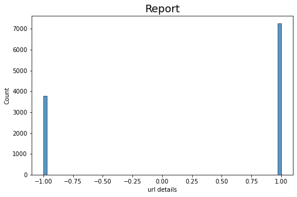

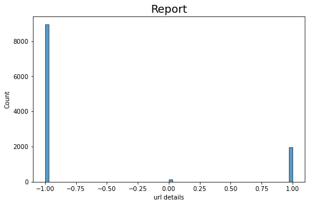

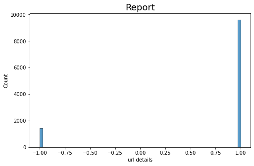

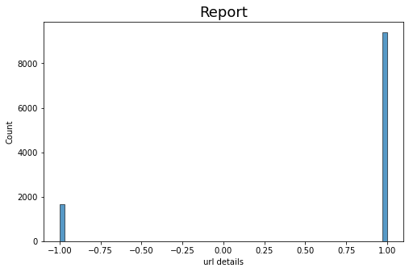

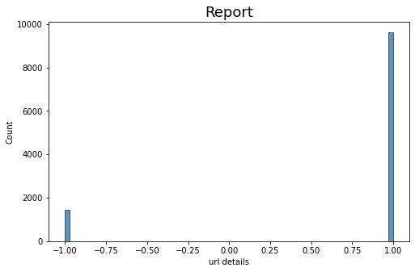

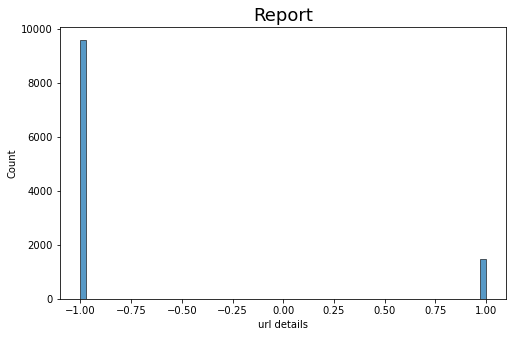

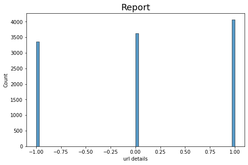

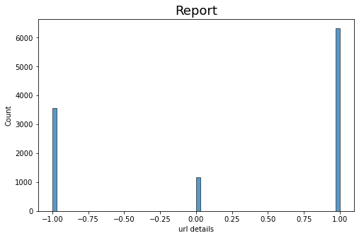

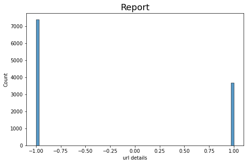

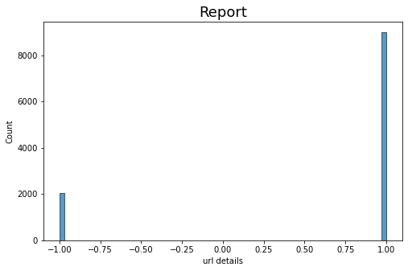

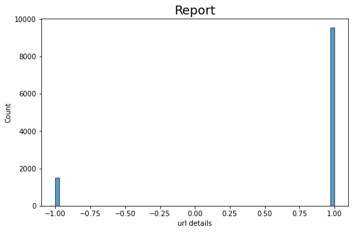

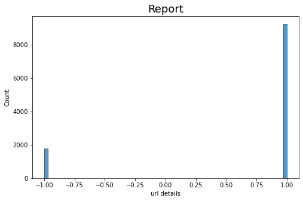

[18 more figures not shown]

```python
plot_data = df.iloc[:, :-1]
plot_data.head(2)
for col in plot_data.columns:
    plt.figure(figsize=(8,5))
    sns.histplot(data=plot_data[col], bins=70)
    plt.xlabel('url details')
    plt.title('Report', size=18)
#     plt.legend()
    plt.show()
```

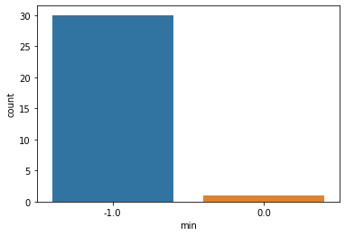

```python
des = df.describe().transpose()
sns.countplot(x = des['min'], data = des)
```

# Correlation of features and feature selection:

### Next, we have to find if there are any correlated features present in the data. Remove the feature which might be correlated with some threshold.

```python
plot_data.corr()
```

|  | having_IPhaving_IP_Address | URLURL_Length | Shortining_Service | having_At_Symbol | double_slash_redirecting | Prefix_Suffix | having_Sub_Domain | SSLfinal_State | Domain_registeration_length | Favicon | ... | RightClick | popUpWidnow | Iframe | age_of_domain | DNSRecord | web_traffic | Page_Rank | Google_Index | Links_pointing_to_page | Statistical_report |
| --- | --- | --- | --- | --- | --- | --- | --- | --- | --- | --- | --- | --- | --- | --- | --- | --- | --- | --- | --- | --- | --- |
| having_IPhaving_IP_Address | 1.000000 | -0.052411 | 0.403461 | 0.158699 | 0.397389 | -0.005257 | -0.080745 | 0.071414 | -0.022739 | 0.087025 | ... | 0.042881 | 0.096882 | 0.054694 | -0.010446 | -0.050733 | 0.002922 | -0.091774 | 0.029153 | -0.339065 | -0.019103 |
| URLURL_Length | -0.052411 | 1.000000 | -0.097881 | -0.075108 | -0.081247 | 0.055247 | 0.003997 | 0.048754 | -0.221892 | -0.042497 | ... | -0.013613 | -0.049381 | -0.013838 | 0.179426 | -0.040823 | 0.008993 | 0.183518 | 0.002902 | -0.022987 | -0.067153 |
| Shortining_Service | 0.403461 | -0.097881 | 1.000000 | 0.104447 | 0.842796 | -0.080471 | -0.041916 | -0.061426 | 0.060923 | 0.006101 | ... | 0.038118 | 0.036616 | 0.016581 | -0.052596 | 0.436064 | -0.047074 | 0.014591 | 0.155844 | -0.198410 | 0.085461 |
| having_At_Symbol | 0.158699 | -0.075108 | 0.104447 | 1.000000 | 0.086960 | -0.011726 | -0.058976 | 0.031220 | 0.015522 | 0.304899 | ... | 0.219503 | 0.290893 | 0.284410 | -0.005499 | -0.047872 | 0.032918 | -0.064735 | 0.037061 | -0.006080 | -0.080357 |
| double_slash_redirecting | 0.397389 | -0.081247 | 0.842796 | 0.086960 | 1.000000 | -0.085590 | -0.043079 | -0.036200 | 0.047464 | 0.035100 | ... | 0.025863 | 0.054463 | 0.010459 | -0.050107 | 0.431409 | -0.062369 | -0.003132 | 0.178415 | -0.194165 | 0.070390 |
| Prefix_Suffix | -0.005257 | 0.055247 | -0.080471 | -0.011726 | -0.085590 | 1.000000 | 0.087891 | 0.261391 | -0.096799 | -0.007504 | ... | -0.024868 | -0.014733 | -0.036904 | 0.074116 | -0.016556 | 0.110598 | -0.006834 | 0.067781 | 0.067423 | -0.002763 |
| having_Sub_Domain | -0.080745 | 0.003997 | -0.041916 | -0.058976 | -0.043079 | 0.087891 | 1.000000 | 0.267649 | -0.082839 | -0.016704 | ... | 0.018230 | -0.025312 | 0.010637 | 0.119254 | 0.125493 | -0.005764 | 0.120730 | 0.057673 | -0.010526 | 0.081627 |
| SSLfinal_State | 0.071414 | 0.048754 | -0.061426 | 0.031220 | -0.036200 | 0.261391 | 0.267649 | 1.000000 | -0.193622 | -0.014757 | ... | 0.015854 | -0.013005 | -0.002773 | 0.162809 | 0.050972 | 0.258768 | 0.074545 | 0.096051 | -0.011710 | 0.063411 |
| Domain_registeration_length | -0.022739 | -0.221892 | 0.060923 | 0.015522 | 0.047464 | -0.096799 | -0.082839 | -0.193622 | 1.000000 | 0.054253 | ... | 0.023520 | 0.051410 | 0.004393 | -0.062851 | -0.010477 | -0.134454 | -0.059898 | -0.039766 | 0.122672 | -0.002212 |
| Favicon | 0.087025 | -0.042497 | 0.006101 | 0.304899 | 0.035100 | -0.007504 | -0.016704 | -0.014757 | 0.054253 | 1.000000 | ... | 0.414382 | 0.939633 | 0.627607 | -0.002628 | 0.088211 | -0.050922 | 0.011699 | -0.016668 | -0.127243 | 0.300917 |
| port | 0.060979 | 0.000323 | 0.002201 | 0.364891 | 0.025060 | -0.022546 | 0.004863 | 0.027473 | 0.022478 | 0.803834 | ... | 0.481631 | 0.748517 | 0.687044 | 0.008459 | 0.054849 | -0.028543 | 0.017954 | -0.005413 | -0.139104 | 0.343987 |
| HTTPS_token | 0.363534 | -0.089383 | 0.757838 | 0.104561 | 0.760799 | -0.070153 | -0.037239 | -0.029941 | 0.059161 | 0.049483 | ... | 0.009265 | 0.066957 | 0.017509 | -0.049632 | 0.395387 | -0.039708 | 0.021104 | 0.115450 | -0.128724 | 0.096187 |
| Request_URL | 0.029773 | 0.246348 | -0.037235 | 0.027909 | -0.026368 | 0.098675 | 0.104857 | 0.193054 | -0.609970 | -0.004620 | ... | -0.020452 | -0.004622 | 0.016934 | 0.090455 | 0.015933 | 0.161166 | 0.055734 | 0.046409 | -0.067109 | 0.035412 |
| URL_of_Anchor | 0.099847 | -0.023396 | 0.000561 | 0.057914 | -0.005036 | 0.348871 | 0.229491 | 0.535786 | -0.160257 | 0.037698 | ... | 0.022168 | 0.041150 | 0.013403 | 0.075508 | 0.093288 | 0.326293 | 0.099261 | 0.038816 | 0.018651 | 0.077377 |
| Links_in_tags | 0.006212 | 0.052869 | -0.133379 | -0.070861 | -0.125583 | 0.100254 | 0.093646 | 0.176825 | -0.101084 | -0.100341 | ... | -0.037469 | -0.112282 | -0.070030 | 0.078057 | -0.038545 | 0.064548 | -0.006450 | 0.045557 | 0.013561 | -0.087343 |
| SFH | -0.010962 | 0.414196 | -0.022723 | -0.008672 | -0.041672 | 0.001326 | 0.096089 | 0.171402 | -0.136422 | -0.012279 | ... | 0.008467 | -0.004863 | 0.007067 | -0.015840 | 0.034440 | 0.052706 | 0.001979 | 0.027588 | -0.009068 | -0.005289 |
| Submitting_to_email | 0.077989 | -0.014457 | 0.049328 | 0.370123 | 0.031898 | -0.045000 | 0.008830 | 0.008062 | 0.039260 | 0.668317 | ... | 0.398629 | 0.629462 | 0.577490 | 0.007357 | 0.064145 | -0.015685 | 0.026208 | -0.008378 | -0.039956 | 0.352074 |
| Abnormal_URL | 0.336549 | -0.106761 | 0.739290 | 0.203945 | 0.723724 | -0.077620 | -0.034908 | -0.046245 | 0.058109 | 0.071848 | ... | 0.023710 | 0.091188 | 0.017590 | -0.032533 | 0.366833 | -0.052416 | 0.007318 | 0.124751 | -0.161027 | 0.186399 |
| Redirect | -0.321181 | 0.046832 | -0.534530 | -0.028160 | -0.591478 | 0.016271 | 0.031206 | -0.021070 | -0.016300 | -0.015621 | ... | -0.023586 | -0.026327 | -0.012668 | -0.022476 | -0.211096 | 0.004631 | 0.052867 | 0.057230 | 0.161278 | -0.059194 |
| on_mouseover | 0.084059 | -0.045103 | 0.062383 | 0.279697 | 0.086635 | 0.012578 | -0.018082 | 0.023586 | 0.023784 | 0.706179 | ... | 0.474054 | 0.733629 | 0.659478 | 0.013306 | 0.087161 | -0.036531 | 0.015634 | -0.006510 | -0.038551 | 0.277347 |
| RightClick | 0.042881 | -0.013613 | 0.038118 | 0.219503 | 0.025863 | -0.024868 | 0.018230 | 0.015854 | 0.023520 | 0.414382 | ... | 1.000000 | 0.415268 | 0.655863 | 0.006764 | 0.038255 | -0.013594 | 0.025341 | -0.008066 | -0.119831 | 0.204409 |
| popUpWidnow | 0.096882 | -0.049381 | 0.036616 | 0.290893 | 0.054463 | -0.014733 | -0.025312 | -0.013005 | 0.051410 | 0.939633 | ... | 0.415268 | 1.000000 | 0.629406 | -0.000948 | 0.098658 | -0.043190 | 0.017114 | -0.010256 | -0.121325 | 0.285261 |
| Iframe | 0.054694 | -0.013838 | 0.016581 | 0.284410 | 0.010459 | -0.036904 | 0.010637 | -0.002773 | 0.004393 | 0.627607 | ... | 0.655863 | 0.629406 | 1.000000 | 0.018848 | 0.047293 | -0.022080 | 0.022407 | -0.003519 | -0.140824 | 0.268418 |
| age_of_domain | -0.010446 | 0.179426 | -0.052596 | -0.005499 | -0.050107 | 0.074116 | 0.119254 | 0.162809 | -0.062851 | -0.002628 | ... | 0.006764 | -0.000948 | 0.018848 | 1.000000 | -0.034082 | 0.089949 | -0.147194 | -0.028471 | 0.040407 | 0.009115 |
| DNSRecord | -0.050733 | -0.040823 | 0.436064 | -0.047872 | 0.431409 | -0.016556 | 0.125493 | 0.050972 | -0.010477 | 0.088211 | ... | 0.038255 | 0.098658 | 0.047293 | -0.034082 | 1.000000 | 0.048650 | 0.137860 | 0.137509 | -0.318266 | 0.136860 |
| web_traffic | 0.002922 | 0.008993 | -0.047074 | 0.032918 | -0.062369 | 0.110598 | -0.005764 | 0.258768 | -0.134454 | -0.050922 | ... | -0.013594 | -0.043190 | -0.022080 | 0.089949 | 0.048650 | 1.000000 | 0.030984 | -0.012584 | -0.019860 | 0.009223 |
| Page_Rank | -0.091774 | 0.183518 | 0.014591 | -0.064735 | -0.003132 | -0.006834 | 0.120730 | 0.074545 | -0.059898 | 0.011699 | ... | 0.025341 | 0.017114 | 0.022407 | -0.147194 | 0.137860 | 0.030984 | 1.000000 | 0.032431 | -0.028216 | 0.031049 |
| Google_Index | 0.029153 | 0.002902 | 0.155844 | 0.037061 | 0.178415 | 0.067781 | 0.057673 | 0.096051 | -0.039766 | -0.016668 | ... | -0.008066 | -0.010256 | -0.003519 | -0.028471 | 0.137509 | -0.012584 | 0.032431 | 1.000000 | -0.038777 | -0.005103 |
| Links_pointing_to_page | -0.339065 | -0.022987 | -0.198410 | -0.006080 | -0.194165 | 0.067423 | -0.010526 | -0.011710 | 0.122672 | -0.127243 | ... | -0.119831 | -0.121325 | -0.140824 | 0.040407 | -0.318266 | -0.019860 | -0.028216 | -0.038777 | 1.000000 | -0.016817 |
| Statistical_report | -0.019103 | -0.067153 | 0.085461 | -0.080357 | 0.070390 | -0.002763 | 0.081627 | 0.063411 | -0.002212 | 0.300917 | ... | 0.204409 | 0.285261 | 0.268418 | 0.009115 | 0.136860 | 0.009223 | 0.031049 | -0.005103 | -0.016817 | 1.000000 |

30 rows × 30 columns

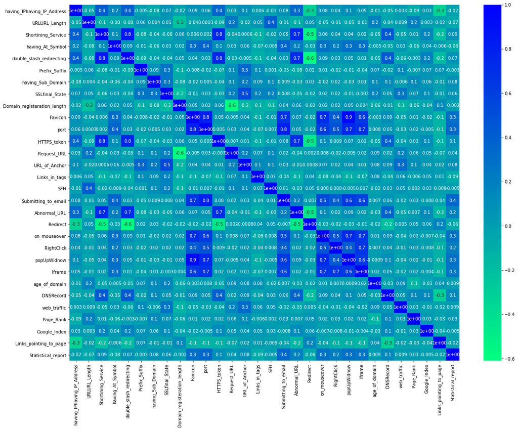

```python
plt.figure(figsize=(20,15))
sns.heatmap(data = plot_data.corr(), fmt='.1', annot=True, cmap='winter_r')
```

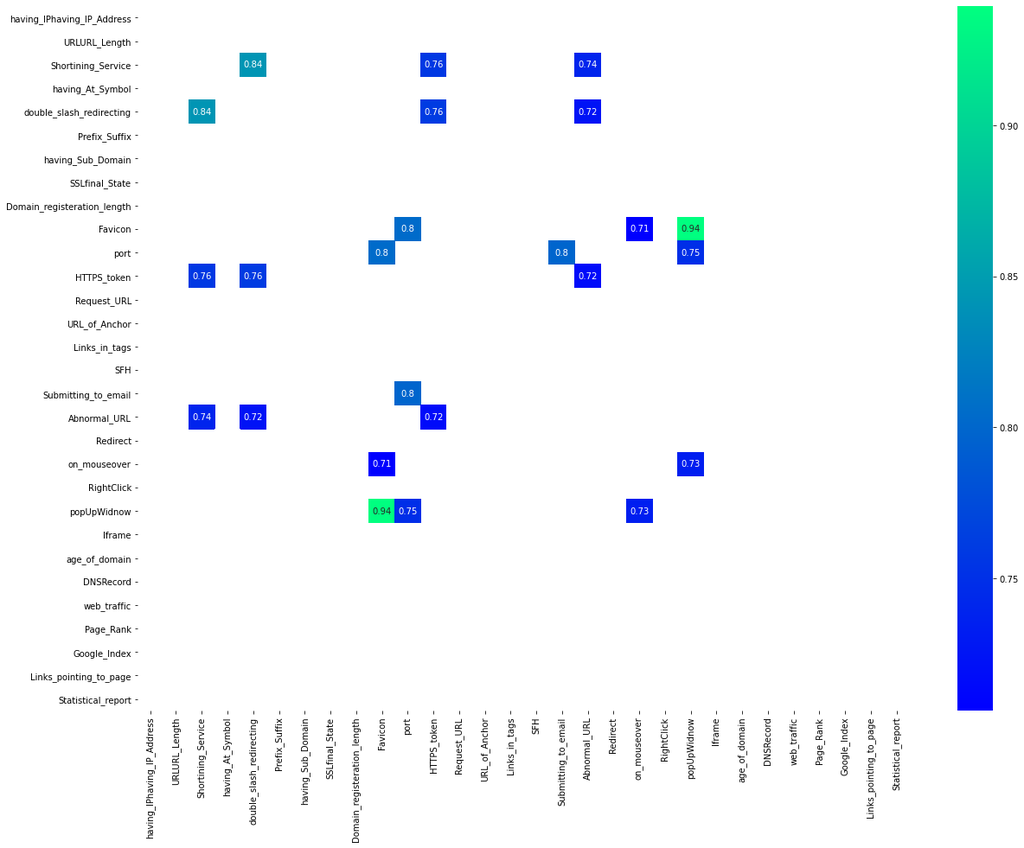

```python
dfcorr = plot_data.corr()
filter_df = dfcorr[((dfcorr >=0.7) | (dfcorr <= -0.7)) & (dfcorr != 1)]
plt.figure(figsize=(20,15))
sns.heatmap(data = filter_df, fmt='.2', annot=True, cmap='winter')
```

```python
filter_df
```

|  | having_IPhaving_IP_Address | URLURL_Length | Shortining_Service | having_At_Symbol | double_slash_redirecting | Prefix_Suffix | having_Sub_Domain | SSLfinal_State | Domain_registeration_length | Favicon | ... | RightClick | popUpWidnow | Iframe | age_of_domain | DNSRecord | web_traffic | Page_Rank | Google_Index | Links_pointing_to_page | Statistical_report |
| --- | --- | --- | --- | --- | --- | --- | --- | --- | --- | --- | --- | --- | --- | --- | --- | --- | --- | --- | --- | --- | --- |
| having_IPhaving_IP_Address | NaN | NaN | NaN | NaN | NaN | NaN | NaN | NaN | NaN | NaN | ... | NaN | NaN | NaN | NaN | NaN | NaN | NaN | NaN | NaN | NaN |
| URLURL_Length | NaN | NaN | NaN | NaN | NaN | NaN | NaN | NaN | NaN | NaN | ... | NaN | NaN | NaN | NaN | NaN | NaN | NaN | NaN | NaN | NaN |
| Shortining_Service | NaN | NaN | NaN | NaN | 0.842796 | NaN | NaN | NaN | NaN | NaN | ... | NaN | NaN | NaN | NaN | NaN | NaN | NaN | NaN | NaN | NaN |
| having_At_Symbol | NaN | NaN | NaN | NaN | NaN | NaN | NaN | NaN | NaN | NaN | ... | NaN | NaN | NaN | NaN | NaN | NaN | NaN | NaN | NaN | NaN |
| double_slash_redirecting | NaN | NaN | 0.842796 | NaN | NaN | NaN | NaN | NaN | NaN | NaN | ... | NaN | NaN | NaN | NaN | NaN | NaN | NaN | NaN | NaN | NaN |
| Prefix_Suffix | NaN | NaN | NaN | NaN | NaN | NaN | NaN | NaN | NaN | NaN | ... | NaN | NaN | NaN | NaN | NaN | NaN | NaN | NaN | NaN | NaN |
| having_Sub_Domain | NaN | NaN | NaN | NaN | NaN | NaN | NaN | NaN | NaN | NaN | ... | NaN | NaN | NaN | NaN | NaN | NaN | NaN | NaN | NaN | NaN |
| SSLfinal_State | NaN | NaN | NaN | NaN | NaN | NaN | NaN | NaN | NaN | NaN | ... | NaN | NaN | NaN | NaN | NaN | NaN | NaN | NaN | NaN | NaN |
| Domain_registeration_length | NaN | NaN | NaN | NaN | NaN | NaN | NaN | NaN | NaN | NaN | ... | NaN | NaN | NaN | NaN | NaN | NaN | NaN | NaN | NaN | NaN |
| Favicon | NaN | NaN | NaN | NaN | NaN | NaN | NaN | NaN | NaN | NaN | ... | NaN | 0.939633 | NaN | NaN | NaN | NaN | NaN | NaN | NaN | NaN |
| port | NaN | NaN | NaN | NaN | NaN | NaN | NaN | NaN | NaN | 0.803834 | ... | NaN | 0.748517 | NaN | NaN | NaN | NaN | NaN | NaN | NaN | NaN |
| HTTPS_token | NaN | NaN | 0.757838 | NaN | 0.760799 | NaN | NaN | NaN | NaN | NaN | ... | NaN | NaN | NaN | NaN | NaN | NaN | NaN | NaN | NaN | NaN |
| Request_URL | NaN | NaN | NaN | NaN | NaN | NaN | NaN | NaN | NaN | NaN | ... | NaN | NaN | NaN | NaN | NaN | NaN | NaN | NaN | NaN | NaN |
| URL_of_Anchor | NaN | NaN | NaN | NaN | NaN | NaN | NaN | NaN | NaN | NaN | ... | NaN | NaN | NaN | NaN | NaN | NaN | NaN | NaN | NaN | NaN |
| Links_in_tags | NaN | NaN | NaN | NaN | NaN | NaN | NaN | NaN | NaN | NaN | ... | NaN | NaN | NaN | NaN | NaN | NaN | NaN | NaN | NaN | NaN |
| SFH | NaN | NaN | NaN | NaN | NaN | NaN | NaN | NaN | NaN | NaN | ... | NaN | NaN | NaN | NaN | NaN | NaN | NaN | NaN | NaN | NaN |
| Submitting_to_email | NaN | NaN | NaN | NaN | NaN | NaN | NaN | NaN | NaN | NaN | ... | NaN | NaN | NaN | NaN | NaN | NaN | NaN | NaN | NaN | NaN |
| Abnormal_URL | NaN | NaN | 0.739290 | NaN | 0.723724 | NaN | NaN | NaN | NaN | NaN | ... | NaN | NaN | NaN | NaN | NaN | NaN | NaN | NaN | NaN | NaN |
| Redirect | NaN | NaN | NaN | NaN | NaN | NaN | NaN | NaN | NaN | NaN | ... | NaN | NaN | NaN | NaN | NaN | NaN | NaN | NaN | NaN | NaN |
| on_mouseover | NaN | NaN | NaN | NaN | NaN | NaN | NaN | NaN | NaN | 0.706179 | ... | NaN | 0.733629 | NaN | NaN | NaN | NaN | NaN | NaN | NaN | NaN |
| RightClick | NaN | NaN | NaN | NaN | NaN | NaN | NaN | NaN | NaN | NaN | ... | NaN | NaN | NaN | NaN | NaN | NaN | NaN | NaN | NaN | NaN |
| popUpWidnow | NaN | NaN | NaN | NaN | NaN | NaN | NaN | NaN | NaN | 0.939633 | ... | NaN | NaN | NaN | NaN | NaN | NaN | NaN | NaN | NaN | NaN |
| Iframe | NaN | NaN | NaN | NaN | NaN | NaN | NaN | NaN | NaN | NaN | ... | NaN | NaN | NaN | NaN | NaN | NaN | NaN | NaN | NaN | NaN |
| age_of_domain | NaN | NaN | NaN | NaN | NaN | NaN | NaN | NaN | NaN | NaN | ... | NaN | NaN | NaN | NaN | NaN | NaN | NaN | NaN | NaN | NaN |
| DNSRecord | NaN | NaN | NaN | NaN | NaN | NaN | NaN | NaN | NaN | NaN | ... | NaN | NaN | NaN | NaN | NaN | NaN | NaN | NaN | NaN | NaN |
| web_traffic | NaN | NaN | NaN | NaN | NaN | NaN | NaN | NaN | NaN | NaN | ... | NaN | NaN | NaN | NaN | NaN | NaN | NaN | NaN | NaN | NaN |
| Page_Rank | NaN | NaN | NaN | NaN | NaN | NaN | NaN | NaN | NaN | NaN | ... | NaN | NaN | NaN | NaN | NaN | NaN | NaN | NaN | NaN | NaN |
| Google_Index | NaN | NaN | NaN | NaN | NaN | NaN | NaN | NaN | NaN | NaN | ... | NaN | NaN | NaN | NaN | NaN | NaN | NaN | NaN | NaN | NaN |
| Links_pointing_to_page | NaN | NaN | NaN | NaN | NaN | NaN | NaN | NaN | NaN | NaN | ... | NaN | NaN | NaN | NaN | NaN | NaN | NaN | NaN | NaN | NaN |
| Statistical_report | NaN | NaN | NaN | NaN | NaN | NaN | NaN | NaN | NaN | NaN | ... | NaN | NaN | NaN | NaN | NaN | NaN | NaN | NaN | NaN | NaN |

30 rows × 30 columns

```python
filter_df.isnull().sum()
```

```
having_IPhaving_IP_Address     30
URLURL_Length                  30
Shortining_Service             27
having_At_Symbol               30
double_slash_redirecting       27
Prefix_Suffix                  30
having_Sub_Domain              30
SSLfinal_State                 30
Domain_registeration_length    30
Favicon                        27
port                           27
HTTPS_token                    27
Request_URL                    30
URL_of_Anchor                  30
Links_in_tags                  30
SFH                            30
Submitting_to_email            29
Abnormal_URL                   27
Redirect                       30
on_mouseover                   28
RightClick                     30
popUpWidnow                    27
Iframe                         30
age_of_domain                  30
DNSRecord                      30
web_traffic                    30
Page_Rank                      30
Google_Index                   30
Links_pointing_to_page         30
Statistical_report             30
dtype: int64
```

```python
filter_df1 = filter_df[filter_df.isnull().sum() != 30]
filter_df1
```

|  | having_IPhaving_IP_Address | URLURL_Length | Shortining_Service | having_At_Symbol | double_slash_redirecting | Prefix_Suffix | having_Sub_Domain | SSLfinal_State | Domain_registeration_length | Favicon | ... | RightClick | popUpWidnow | Iframe | age_of_domain | DNSRecord | web_traffic | Page_Rank | Google_Index | Links_pointing_to_page | Statistical_report |
| --- | --- | --- | --- | --- | --- | --- | --- | --- | --- | --- | --- | --- | --- | --- | --- | --- | --- | --- | --- | --- | --- |
| Shortining_Service | NaN | NaN | NaN | NaN | 0.842796 | NaN | NaN | NaN | NaN | NaN | ... | NaN | NaN | NaN | NaN | NaN | NaN | NaN | NaN | NaN | NaN |
| double_slash_redirecting | NaN | NaN | 0.842796 | NaN | NaN | NaN | NaN | NaN | NaN | NaN | ... | NaN | NaN | NaN | NaN | NaN | NaN | NaN | NaN | NaN | NaN |
| Favicon | NaN | NaN | NaN | NaN | NaN | NaN | NaN | NaN | NaN | NaN | ... | NaN | 0.939633 | NaN | NaN | NaN | NaN | NaN | NaN | NaN | NaN |
| port | NaN | NaN | NaN | NaN | NaN | NaN | NaN | NaN | NaN | 0.803834 | ... | NaN | 0.748517 | NaN | NaN | NaN | NaN | NaN | NaN | NaN | NaN |
| HTTPS_token | NaN | NaN | 0.757838 | NaN | 0.760799 | NaN | NaN | NaN | NaN | NaN | ... | NaN | NaN | NaN | NaN | NaN | NaN | NaN | NaN | NaN | NaN |
| Submitting_to_email | NaN | NaN | NaN | NaN | NaN | NaN | NaN | NaN | NaN | NaN | ... | NaN | NaN | NaN | NaN | NaN | NaN | NaN | NaN | NaN | NaN |
| Abnormal_URL | NaN | NaN | 0.739290 | NaN | 0.723724 | NaN | NaN | NaN | NaN | NaN | ... | NaN | NaN | NaN | NaN | NaN | NaN | NaN | NaN | NaN | NaN |
| on_mouseover | NaN | NaN | NaN | NaN | NaN | NaN | NaN | NaN | NaN | 0.706179 | ... | NaN | 0.733629 | NaN | NaN | NaN | NaN | NaN | NaN | NaN | NaN |
| popUpWidnow | NaN | NaN | NaN | NaN | NaN | NaN | NaN | NaN | NaN | 0.939633 | ... | NaN | NaN | NaN | NaN | NaN | NaN | NaN | NaN | NaN | NaN |

9 rows × 30 columns

```python
res = filter_df1.drop(['having_IPhaving_IP_Address', 'URLURL_Length',
       'having_At_Symbol', 'Prefix_Suffix',
       'having_Sub_Domain', 'SSLfinal_State', 'Domain_registeration_length',
       'Request_URL', 'URL_of_Anchor',
       'Links_in_tags', 'SFH', 'Redirect', 'RightClick', 'Iframe',
       'age_of_domain', 'DNSRecord', 'web_traffic', 'Page_Rank',
       'Google_Index', 'Links_pointing_to_page', 'Statistical_report'], axis='columns'
                     )
res
```

|  | Shortining_Service | double_slash_redirecting | Favicon | port | HTTPS_token | Submitting_to_email | Abnormal_URL | on_mouseover | popUpWidnow |
| --- | --- | --- | --- | --- | --- | --- | --- | --- | --- |
| Shortining_Service | NaN | 0.842796 | NaN | NaN | 0.757838 | NaN | 0.739290 | NaN | NaN |
| double_slash_redirecting | 0.842796 | NaN | NaN | NaN | 0.760799 | NaN | 0.723724 | NaN | NaN |
| Favicon | NaN | NaN | NaN | 0.803834 | NaN | NaN | NaN | 0.706179 | 0.939633 |
| port | NaN | NaN | 0.803834 | NaN | NaN | 0.799088 | NaN | NaN | 0.748517 |
| HTTPS_token | 0.757838 | 0.760799 | NaN | NaN | NaN | NaN | 0.716287 | NaN | NaN |
| Submitting_to_email | NaN | NaN | NaN | 0.799088 | NaN | NaN | NaN | NaN | NaN |
| Abnormal_URL | 0.739290 | 0.723724 | NaN | NaN | 0.716287 | NaN | NaN | NaN | NaN |
| on_mouseover | NaN | NaN | 0.706179 | NaN | NaN | NaN | NaN | NaN | 0.733629 |
| popUpWidnow | NaN | NaN | 0.939633 | 0.748517 | NaN | NaN | NaN | 0.733629 | NaN |

```python
# dropping highly corelated column
X = df.drop(['Favicon', 'HTTPS_token', 'popUpWidnow', 'Result'], axis = 1)
X.head()
```

|  | having_IPhaving_IP_Address | URLURL_Length | Shortining_Service | having_At_Symbol | double_slash_redirecting | Prefix_Suffix | having_Sub_Domain | SSLfinal_State | Domain_registeration_length | port | ... | on_mouseover | RightClick | Iframe | age_of_domain | DNSRecord | web_traffic | Page_Rank | Google_Index | Links_pointing_to_page | Statistical_report |
| --- | --- | --- | --- | --- | --- | --- | --- | --- | --- | --- | --- | --- | --- | --- | --- | --- | --- | --- | --- | --- | --- |
| 0 | -1 | 1 | 1 | 1 | -1 | -1 | -1 | -1 | -1 | 1 | ... | 1 | 1 | 1 | -1 | -1 | -1 | -1 | 1 | 1 | -1 |
| 1 | 1 | 1 | 1 | 1 | 1 | -1 | 0 | 1 | -1 | 1 | ... | 1 | 1 | 1 | -1 | -1 | 0 | -1 | 1 | 1 | 1 |
| 2 | 1 | 0 | 1 | 1 | 1 | -1 | -1 | -1 | -1 | 1 | ... | 1 | 1 | 1 | 1 | -1 | 1 | -1 | 1 | 0 | -1 |
| 3 | 1 | 0 | 1 | 1 | 1 | -1 | -1 | -1 | 1 | 1 | ... | 1 | 1 | 1 | -1 | -1 | 1 | -1 | 1 | -1 | 1 |
| 4 | 1 | 0 | -1 | 1 | 1 | -1 | 1 | 1 | -1 | 1 | ... | -1 | 1 | 1 | -1 | -1 | 0 | -1 | 1 | 1 | 1 |

5 rows × 27 columns

```python
y = df['Result']
y.head()
```

```
0   -1
1   -1
2   -1
3   -1
4    1
Name: Result, dtype: int64
```

# Building Classification Model

Finally, build a robust classification system that classifies whether the URL sample is a phishing site or not.

Build classification models using a binary classifier to detect malicious or phishing URLs.

Illustrate the diagnostic ability of this binary classifier by plotting the ROC curve.

Validate the accuracy of data by the K-Fold cross-validation technique.

The final output consists of the model, which will give maximum accuracy on the validation dataset with selected attributes.

```python
from sklearn.model_selection import train_test_split
```

```python
X_train, X_test, y_train, y_test = train_test_split(X, y, test_size=0.2, random_state=234)
```

```python
X_train.shape, X_test.shape
```

```
((8844, 27), (2211, 27))
```

```python
y_train.shape, y_test.shape
```

```
((8844,), (2211,))
```

```python
# model Creating
```

```python
from sklearn.linear_model import LogisticRegression
```

```python
model = LogisticRegression()
```

```python
model.fit(X_train, y_train)
```

```
LogisticRegression()
```

```python
# prediction
```

```python
y_predict = model.predict(X_test)
```

```python
y_predict[0:5]
```

```
array([-1,  1, -1,  1,  1], dtype=int64)
```

### Illustrate the diagnostic ability of this binary classifier by plotting the ROC curve.

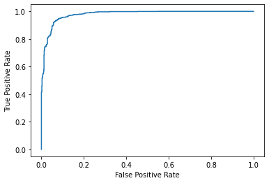

```python
#define metrics
from sklearn import metrics

y_pred_proba = model.predict_proba(X_test)[::,1]
fpr, tpr, _ = metrics.roc_curve(y_test,  y_pred_proba)

#create ROC curve
plt.plot(fpr,tpr)
plt.ylabel('True Positive Rate')
plt.xlabel('False Positive Rate')
plt.show()
```

### Validate the accuracy of data by the K-Fold cross-validation technique.

```python
from sklearn.model_selection import KFold
from sklearn.model_selection import cross_val_score
from numpy import mean
from numpy import absolute
from numpy import sqrt


#define cross-validation method to use
cv = KFold(n_splits=10, random_state=1, shuffle=True)

#build multiple linear regression model
model = LogisticRegression()

#use k-fold CV to evaluate model
scores = cross_val_score(model, X, y, scoring='neg_mean_absolute_error',
                         cv=cv, n_jobs=-1)

#view mean absolute error
mean(absolute(scores))
```

```
0.14418482485496628
```

### The final output consists of the model, which will give maximum accuracy on the validation dataset with selected attributes.

```python
from sklearn.metrics import accuracy_score, f1_score, precision_score, confusion_matrix
```

```python
accuracy_score(y_test, y_predict)
```

```
0.9344188150158299
```

```python
f1_score(y_test, y_predict)
```

```
0.9412241588974463
```

```python
precision_score(y_test, y_predict)
```

```
0.935535858178888
```

```python
confusion_matrix(y_test, y_predict)
```

```
array([[ 905,   80],
       [  65, 1161]], dtype=int64)
```

# Decision tree classifier

```python
from sklearn.tree import DecisionTreeClassifier
model = DecisionTreeClassifier()
model.fit(X_train, y_train)

# prediction
y_predict = model.predict(X_test)
print('predictions:', y_predict[0:5],'\n')
```

```
predictions: [-1  1 -1 -1  1]
```

### Illustrate the diagnostic ability of this binary classifier by plotting the ROC curve.

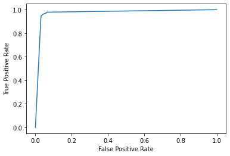

```python
#define metrics
from sklearn import metrics

y_pred_proba = model.predict_proba(X_test)[::,1]
fpr, tpr, _ = metrics.roc_curve(y_test,  y_pred_proba)

#create ROC curve
plt.plot(fpr,tpr)
plt.ylabel('True Positive Rate')
plt.xlabel('False Positive Rate')
plt.show()
```

### Validate the accuracy of data by the K-Fold cross-validation technique.

```python
from sklearn.model_selection import KFold
from sklearn.model_selection import cross_val_score
from numpy import mean
from numpy import absolute
from numpy import sqrt


#define cross-validation method to use
cv = KFold(n_splits=10, random_state=1, shuffle=True)

#build multiple linear regression model
model = DecisionTreeClassifier()

#use k-fold CV to evaluate model
scores = cross_val_score(model, X, y, scoring='neg_mean_absolute_error',
                         cv=cv, n_jobs=-1)

#view mean absolute error
mean(absolute(scores))
```

```
0.07381227856283701
```

### The final output consists of the model, which will give maximum accuracy on the validation dataset with selected attributes.

```python
# The final output consists of the model, which will give maximum accuracy on the validation dataset with selected attributes.
from sklearn.metrics import accuracy_score, f1_score, precision_score
print('Accuracy Score: ',accuracy_score(y_test, y_predict),'\n')
print('F1 Score: ',f1_score(y_test, y_predict),'\n')
print('Precision Score: ',precision_score(y_test, y_predict),'\n')
print('Confusion Matrix:\n' ,confusion_matrix(y_test, y_predict))
```

```
Accuracy Score:  0.9597467209407508

F1 Score:  0.9637474541751527

Precision Score:  0.9625711960943857

Confusion Matrix:
 [[ 939   46]
 [  43 1183]]
```

# Random Forest classifier

```python
from sklearn.ensemble import RandomForestClassifier
model = RandomForestClassifier(n_estimators=1000)
model.fit(X_train, y_train)

# prediction
y_predict = model.predict(X_test)
print('predictions:', y_predict[0:5],'\n')
```

```
predictions: [ 1  1 -1 -1  1]
```

### Illustrate the diagnostic ability of this binary classifier by plotting the ROC curve.

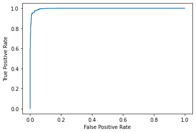

```python
#define metrics
from sklearn import metrics

y_pred_proba = model.predict_proba(X_test)[::,1]
fpr, tpr, _ = metrics.roc_curve(y_test,  y_pred_proba)

#create ROC curve
plt.plot(fpr,tpr)
plt.ylabel('True Positive Rate')
plt.xlabel('False Positive Rate')
plt.show()
```

### Validate the accuracy of data by the K-Fold cross-validation technique.

```python
from sklearn.model_selection import KFold
from sklearn.model_selection import cross_val_score
from numpy import mean
from numpy import absolute
from numpy import sqrt


#define cross-validation method to use
cv = KFold(n_splits=10, random_state=1, shuffle=True)

#build multiple linear regression model
model = RandomForestClassifier()

#use k-fold CV to evaluate model
scores = cross_val_score(model, X, y, scoring='neg_mean_absolute_error',
                         cv=cv, n_jobs=-1)

#view mean absolute error
mean(absolute(scores))
```

```
0.055358758888170656
```

### The final output consists of the model, which will give maximum accuracy on the validation dataset with selected attributes.

```python
# The final output consists of the model, which will give maximum accuracy on the validation dataset with selected attributes.
from sklearn.metrics import accuracy_score, f1_score, precision_score
print('Accuracy Score: ',accuracy_score(y_test, y_predict),'\n')
print('F1 Score: ',f1_score(y_test, y_predict),'\n')
print('Precision Score: ',precision_score(y_test, y_predict),'\n')
print('Confusion Matrix:\n' ,confusion_matrix(y_test, y_predict))
```

```
Accuracy Score:  0.9701492537313433

F1 Score:  0.9733009708737864

Precision Score:  0.9654895666131621

Confusion Matrix:
 [[ 942   43]
 [  23 1203]]
```